# Sets, functions and relations

Autumn 2025

## Objectives

- Define the term **set** in mathematics.
- Perform **set operations** union, intersection, difference.
- Define **cardinality**; compute cardinalities of finite sets and compare cardinalities of infinite sets.
- Give the difference between a **function** and a **relation**, with examples.

## First, a puzzle

## What comes next

| Input | Output |
| --- | --- |
| 9 | 90 |
| 8 | 72 |
| 7 | 56 |
| 6 | 42 |
| 3 | **?** |

What is the output for input \(3\)?

## Multiple solutions

| Input |  | Output |
| --- | --- | --- |
| 9 | \(10 \cdot 9\) | 90 |
| 8 | \(9 \cdot 8\) | 72 |
| 7 | \(8 \cdot 7\) | 56 |
| 6 | \(7 \cdot 6\) | 42 |
| 3 | \(6 \cdot 3\) | **18** |

| Input |  | Output |
| --- | --- | --- |
| 9 | \((9 + 1) \cdot 9\) | 90 |
| 8 | \((8 + 1) \cdot 8\) | 72 |
| 7 | \((7 + 1) \cdot 7\) | 56 |
| 6 | \((6 + 1) \cdot 6\) | 42 |
| 3 | \((3 + 1) \cdot 3\) | **12** |
| \(x\) | \((x + 1) \cdot x\) | \(y\) |

## Sets

## Definition

- Collection of objects,
- in no particular order,
- with no duplicates.

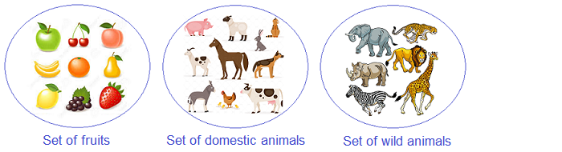

Let’s divide the class into sets based on their answer.

- **A**: those who said 18,
- **B**: those who said 12,
- **C**: those who said “it’s nonsense”,
- **D**: those who politely declined to answer.

Let’s divide the class into sets based on their answer.

[figure not shown]

Each of these sets is **disjoint** (has no elemnts in common).

## Membership

- Written as comma-separated lists of elements:
  - \(A = \{ 0,1,2,3,4,5,6,7,8,9 \}\)
  - \(B = \{ \text{Red}, \text{Green}, \text{Blue} \}\)
  - E.g., \(5\) is member of \(A\).
    - but *Pink* is not a member of \(B\).
  - In symbols we write \(5 \in A\), Pink \(\not \in B\).

## Subsets

- Let \(\mathrm{Ve}\) be the set of all foods vegans can consume
- Let \(\mathrm{V}\) be the set of all foods vegetarians can consume
- Let \(\mathrm{Gf}\) be the set of all foods those on a gluten-free diet can consume

The set \(A\) is a **subset** of the set \(B\) if all elements from \(A\) are in \(B\).

- \(\mathrm{Ve}\subset \mathrm{V}\),

  since vegetarians can consume all foods that vegans can consume
- but \(\mathrm{Gf} \not \subset \mathrm{V}\),

  because there are some vegetarian foods which contain gluten.
- Note: \(A \subset A\).

## Union

- Let \(U\) be the set of all people who eat scones with jam and cream
- \(J\), which is a subset of \(U\), put the jam on first
- \(C\), which is also a subset of \(U\), put the cream on first.

The **union** of \(A\) and \(B\) consists of all elements in *either* \(A\) or \(B\).

- \(J \cup C\) is the set of people who put the jam on first, or those who put the cream on first.

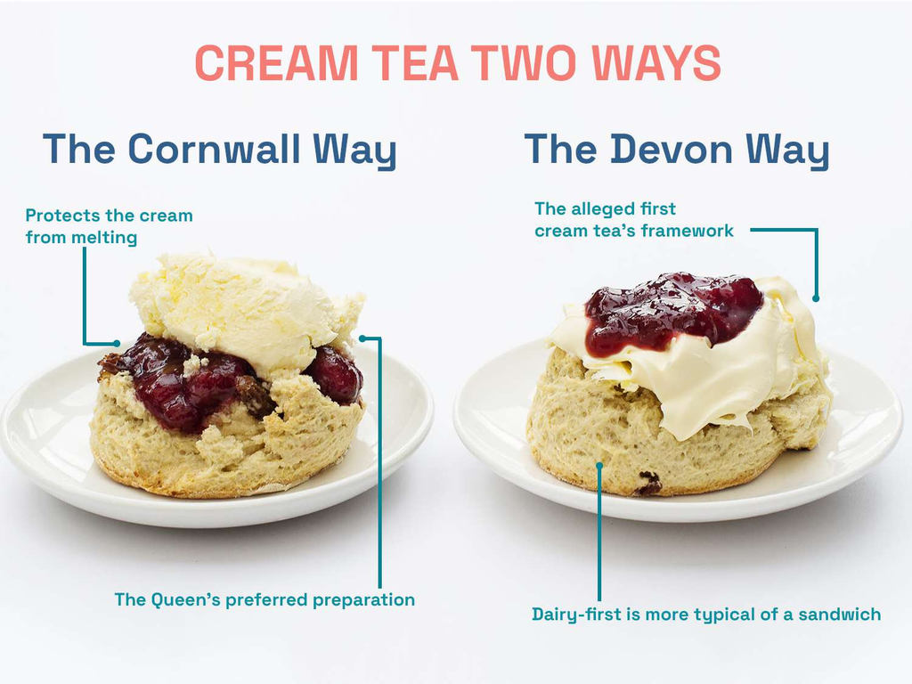

Scones: jam vs cream first

- …in other words, an argument.

## Intersection

- Let \(B\) be the set of all birds
- Let \(F\) be the set of all creatures which cannot fly

The **intersection** of sets \(A\) and \(B\) is the set of elements which are in *both* \(A\) and \(B\).

- \(B\cap F\) is the set of all flightless birds.

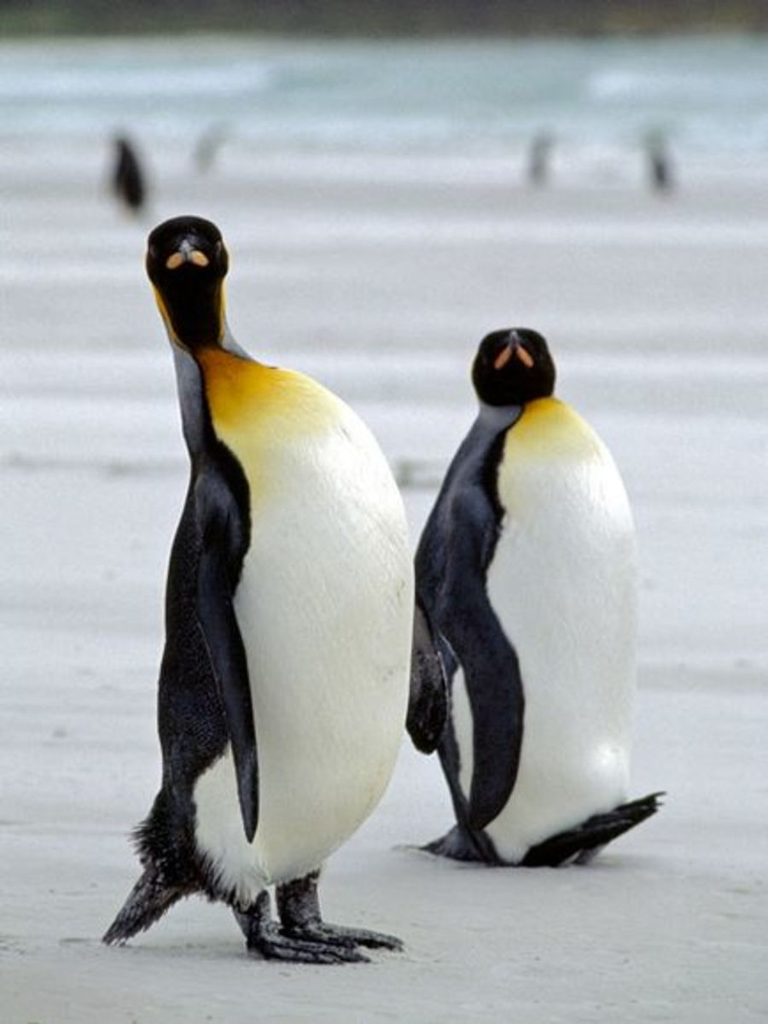

Penguins

## Animal taxonomy is hard

Draw a Venn diagram of

- **A**: Creatures that absorb oxygen from the *air*,
- **W**: Creatures that absorb oxygen from the *water*,
- What is the intersection of **A** and **W**?

## Compliment

- Let \(E\) be the set of all edible things

  (e.g., scones, tripe, rice paper)

The compliment of the set \(A\) is the set of all things in the *universe* which are **not in** \(A\)

- \(E'\) is the set of all inedible things.

  (Commons building, all of the prime numbers, Hollie’s cooking)

## Difference

- Let \(\mathrm{Ve}\) be the set of all foods consumed by vegans
- Let \(\mathrm{G}\) be the set of all foods which contain gluten

The **difference** of sets \(A\) and \(B\) is the set of all elements in \(A\) but not in \(B\).

- \(\mathrm{Ve} \setminus \mathrm{G}\) (or \(\mathrm{Ve}\) without \(\mathrm{G}\)) is
- all the foods consumed by vegans **and** do **not** contain gluten

## Symmetric Difference

- Let \(R\) be the set of all red things
- Let \(O\) be the set of all round things

The **symmetric difference** of two sets \(A\) and \(B\) is the set of all elements in the *union* of \(A\) and \(B\), but *not in the intersection* of \(A\) and \(B\).

- An element is in \(R \cup O\) if it is either *red* or *round*.
- It is in \(R \cap O\) if it is *red* and *round*.
- It is in \((R \cup O) \setminus (R \cap O)\) if it is *red but not round*, or *round but not red*.

## Politics

- **A**: thinks feminism is a bad thing

  \(74\%\) likely to vote to leave the EU
- **B**: Church of England

  \(60\%\) likely to vote to leave the EU
- **C**: over 45 years of age

  \(58\%\) likely to vote to leave the EU

[figure not shown]

Venn diagram

- Those in \(A \cap B \cap C\) were \(90\%\) likely to vote to leave the EU.

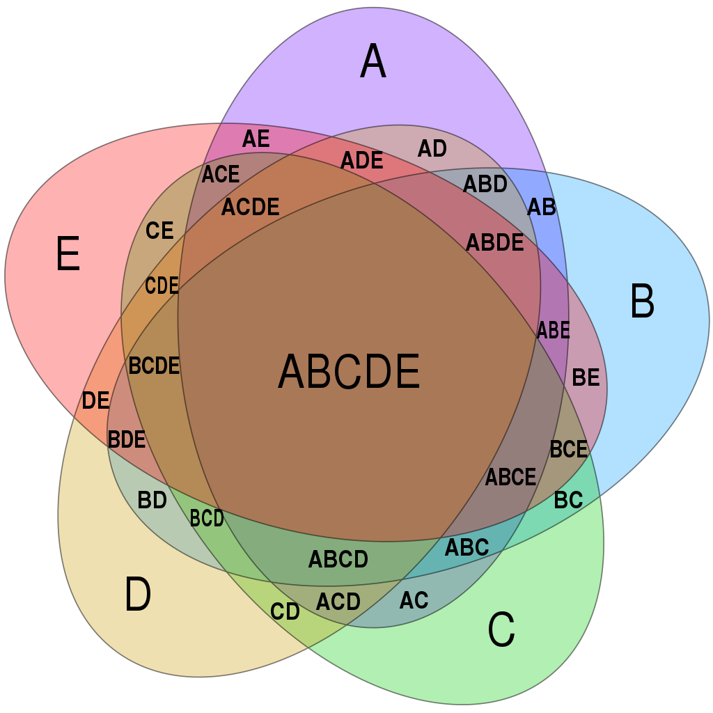

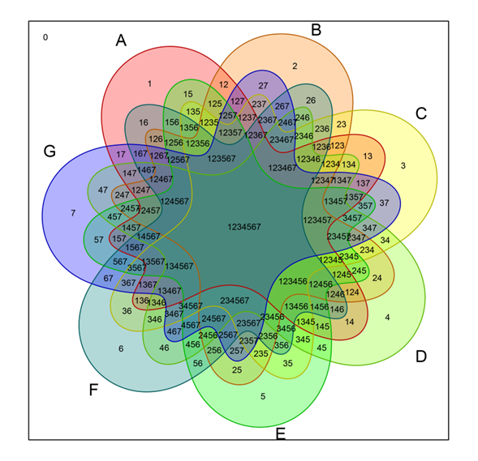

Euler diagrams only show relevant relationships

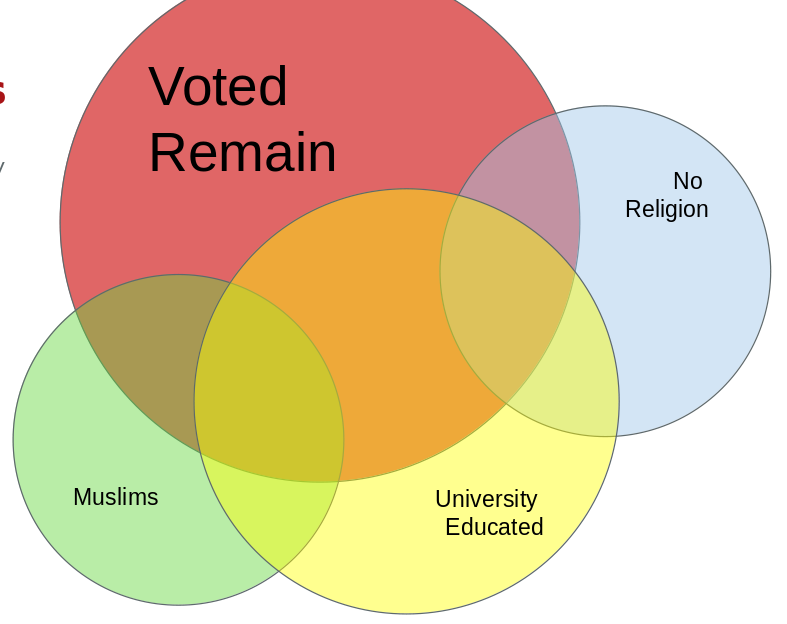

- E.g., the intersection between “Muslim” and “no religion” is empty.

## Cartesian Product

- Let \(C = \{\text{Red}, \text{Green}, \text{Blue}\}\)
- Let \(B = \{0, 1\}\)

The **Cartesian product** of two sets \(A\) and \(B\) is the set of *all pairs* constructed by taking one element from \(A\) and one element from \(B\).

- \(C\times B = \{ (\text{Red}, 0), (\text{Red}, 1), (\text{Green}, 0), (\text{Green}, 1), (\text{Blue},0), (\text{Blue}, 1) \}\)

You can take the Cartesian product of a set with itself.

- Let \(P\) be the set of all people in class,
- Then \(P\times P\) is the set of all pairs of people in class.
- We could use this to partner people up, but there is a problem
- For each person \(a \in P\), \((a,a)\) is a valid pair in the Cartesian product, but we shouldn’t pair a person with themself,
- We’ll need to add some restrictions:

  a person cannot be paired with themself.

## Relations

Formally, a relation on a set \(A\) is a set of pairs; a subset of \(A \times A\).

- Let \(P\) be the set of all people in class,
- Let \(P \times P\) be the Cartesian product of \(P\) by itself.
- For each pair, \((a,b)\), \(a\) is related to \(b\) if \(a\) is not equal to \(b\)

  cannot pair with yourself.

Let \(A = \{ a, b, c\}\)

We could write out a relation as a set of pairs

- \((a, a)\)
- \((a, b)\)
- \((b, c)\)
- \((b, a)\)
- \((c, a)\)
- \((c, b)\)

Or draw a picture

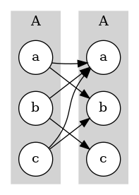

Relation on \(A\)

## Blood types

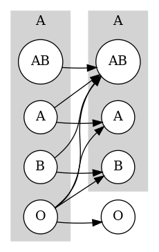

- Type \(O\) can receive from only type \(O\),
- Type \(A\) can receive from type \(O\) or \(A\),
- Type \(B\) can receive from type \(O\) or \(B\),
- Type \(AB\) can receive from all types.

[interactive chart not shown]

## Mathematical relations

- \(=\): two elements are related if they are **equal**
  - *equality* must be defined
  - special type of relation, called an *equivalence relation*
- \(\subset\): \(A\) is related to \(B\) if every element in \(A\) is an element in \(B\)
  - type of *order relation*
- \(<\) and \(\le\)
- \(>\) and \(\ge\)
- Congruence modulo \(n\) (clock arithmetic)

  \(a \equiv b \mod n\) if \(a\) and \(b\) have the same remainder when divided by \(n\)

## Function

A function is a special type of relation

- Defines a rule which relates two sets, \(A\) and \(B\)
- \(A\) is called the **domain**:

  all possible input values
- \(B\) is called the **co-domain** (or range):

  all possible output values
- every element in the domain must be related to **exactly one** element in the co-domain.

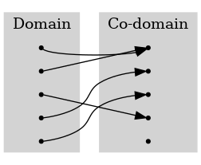

## One-to-one functions

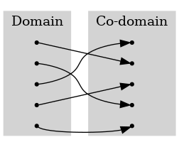

One-to-one function

- Each element in the *co-domain* has **exactly one** pre-image in the *domain*.
- We can *invert* the function, i.e., construct a function which reverses the current function.

## Cardinality

- The **cardinality** of a set is the *number of elements* in the set.
- for finite sets, we simply count the elements.
  - People present in \(G32\) right now,
  - Stones in Wales
  - Letter `e`’s on this slide.
  - Atoms in the chair you are sat on

## Cardinality

Two sets \(A\) and \(B\) have the same cardinality if every element from \(A\) has a *buddy* in \(B\).

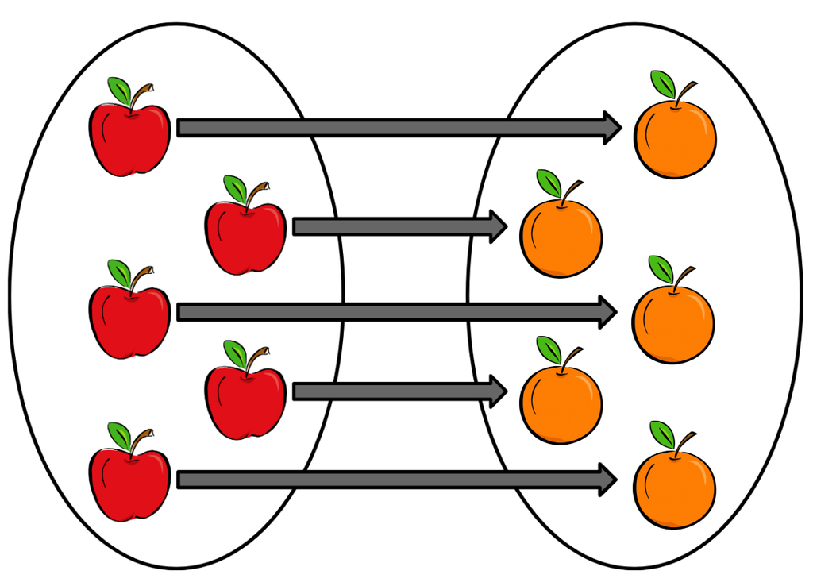

There is a one-to-one function between \(A\) and \(B\).

## Infinities

- How many counting numbers are there?

  \(0, 1, 2, 3, 4, 5, \ldots, 105, 106, \ldots 1109436, 1109437, \ldots\)
- Cantor defined the number of counting numbers as **infinity**

## Infinities

So how many **even** counting numbers are there?

\[0, 2, 4, 6, 8, 10, \ldots\]

- There are infinitely many even numbers
- But is there *half* the number of even counting numbers as counting numbers?
- No – we can construct a one-to-one function from the counting numbers to the even counting numbers.

  \(0 \mapsto 0, 1 \mapsto 2, 2\mapsto 4, 3 \mapsto 6, 4 \mapsto 8, \ldots\)

## Hilbert’s hotel

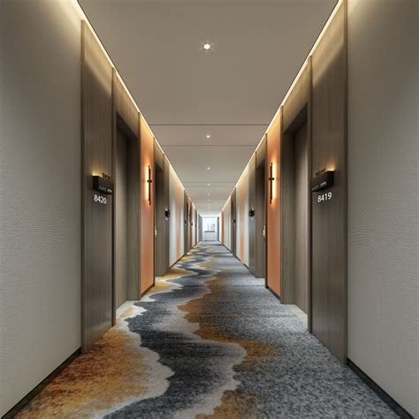

## Hilbert’s hotel

[figure not shown]

- The next day, infinitely many more guests arrive.
- What do we do now?
- \(0 \mapsto 0, 1 \mapsto 2, 2\mapsto 4, 3 \mapsto 6, 4 \mapsto 8, \ldots\)
- \(2 \cdot \infty = \infty\)

## Are counting numbers enough?

- We say a set is **closed** under an operation if the result of the operation gives us another element of the set.
- Counting numbers are closed under addition and multiplication

  \(3 + 4 = 7, 3 \cdot 4 = 12\)

## Mixing paint

- Let \(P = \{\text{Red}, \text{Green}, \text{Blue}\}\)

  be a set of three coloured paints.
- \(P\) is not closed under the operation of *mixing paint*.
- E.g., \(\text{Red}\ast_\text{mix}\text{Blue} = \text{Purple}\), which is not in \(P\).
- Counting numbers are closed under addition and multiplication

  \(3 + 4 = 7, 3 \cdot 4 = 12\)
- But not subtraction

  \(5 - 3 = 2, 3 - 5 = ?\)
- Or division

  \(12 / 3 = 4, 3 / 12 = 1 / 4 = ?\)

## Integers and fractions

- We can pair up the integers with the counting numbers

  \(0, -1, 1, -2, 2, -3, 3, -4, 4, \ldots\)
- It is also possible (but more technically difficult) to do this with the rationals.

## Irrational numbers

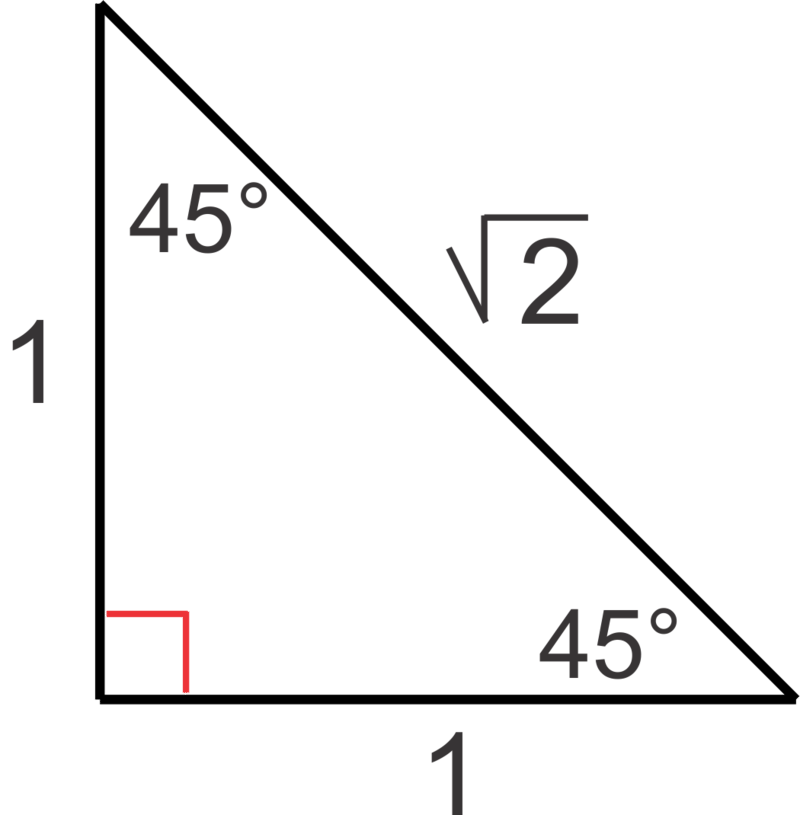

Triangle with sides of length \(1, 1, \sqrt{2}\)

- Fold a square of paper in half: two sides have length \(1\).
- The long side has length \(\sqrt{1^2 + 1^2} = \sqrt{2}\)

## Are the fractions closed under square root?

- Can we express \(\sqrt{2}\) as a fraction?
- \(\dfrac 1 1, \dfrac 3 2, \dfrac 7 5, \dfrac {17} {12}, \dfrac {41} {29}, \dfrac {99} {70}, \dfrac {239} {169}, \dfrac {577} {408}, \ldots\)
- …close, but we’ll never get there (it can be proved!)

The Greeks were confounded!

- The *irrational* numbers were born

## The reals

The *irrational* numbers, together with the *rational* numbers form the **real** numbers.

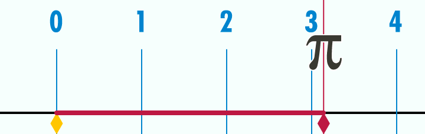

[figure not shown]

## Counting the real numbers

- How many real numbers are there?
- Cantor proved that there are **more** real numbers than rational numbers

  (check out https://youtu.be/elvOZm0d4H0)
- Most of the real numbers are irrational
  - actually most of the real numbers are transcendental

## Sets of sets

- Sets can contain other sets
- E.g., we can define “three-ness” as

  the set of all sets containing three elements
- Sometimes sets of sets can contain themselves

  e.g., the set of all inedible things includes the set of all inedible things.
  - More on that later …
- The powerset of a set \(A\) is defined as

  the set of all possible subsets of \(A\)

## Power set

- We write \(2^A\) to mean the power set of the set \(A\).

  (there’s a good reason for that notation)
- Let \(A\) be the set {*apples*, *oranges*, *bananas*},

  we can list all subsets as follows
  1. {*apple*, *orange*, *banana*},
  2. {*apple*, *orange*},
  3. {*apple*, *banana*},
  4. {*orange*, *banana*},
  5. {*apple*},
  6. {*orange*},
  7. {*banana*},
  8. {}
- Constructing the power set:
  - for each element \(a\) of \(A\),
  - Decide whether to…
    - … place \(a\) in the candidate set (\(1\))
    - … or discard \(a\) (\(0\)).
  - If \(A\) contains \(n\) elements, then this process results in a sequence of decisions

    e.g., \((0, 0, 1, 0, 1, \ldots, 1)\)

## Power set of the natural numbers

- We saw that the set of all **real** numbers is uncountable.
- But what about the powerset of the natural numbers?

  (the set of all subsets of the natural numbers)

If they are countable, then we can write them out:

\[ \begin{align*} s_{0}=&(0,0,0,0,0,0,0,0,\ldots)\\s_{1}=&(1,1,1,1,1,1,1,1,\ldots)\\s_{2}=&(1,0,1,0,1,0,1,0,\ldots)\\s_{3}=&(0,1,0,1,0,1,0,1,\ldots)\\s_{4}=&(1,0,0,1,0,0,1,0,\ldots)\\s_{5}=&(0,1,1,0,1,1,0,1,\ldots)\\s_{6}=&(1,1,0,1,1,0,1,1,\ldots)\\&\vdots \end{align*} \]

As a sequence of decisions. I.e., \((0,1,1,1,\ldots)\) says to include every natural number except the first.

We can construct a new sequence as follows

\[ \begin{align} s_{0}=&(\underline{0},0,0,0,0,0,0,0,\ldots)\\s_{1}=&(1,\underline{1},1,1,1,1,1,1,\ldots)\\s_{2}=&(1,0,\underline{1},0,1,0,1,0,\ldots)\\s_{3}=&(0,1,0,\underline{1},0,1,0,1,\ldots)\\s_{4}=&(1,0,0,1,\underline{0},0,1,0,\ldots)\\s_{5}=&(0,1,1,0,1,\underline{1},0,1,\ldots)\\s_{6}=&(1,1,0,1,1,0,\underline{1},1,\ldots)\\&\vdots \end{align} \]

- Take all the diagonal elemens \((0,1,1,1,0,1,1,\ldots)\),
- Then flip each digit

  \(S = (1,0,0,0,1,0,0,\ldots)\)
- \(S\) defines a subset of the natural numbers.
- The \(i\)-th digit of \(S\) is different from the \(i\)-th digit of sequence \(i\).
- OK, but what if the \(i\)-th digit of \(S\) is the same as the \(j\)-th digit of sequence \(j\)…
  - then the \(j\)-the digit of \(S\) is different from the \(j\)-the digit of the \(j\)-th sequence.
- I.e., \(S\) is different in at least one place from *every* sequence we generated.
- \(S\) is a new sequence – the power set of the natural numbers cannot be listed!
- This is the idea behind Cantor’s diagonalisation argument.

## Lab task

- Select three sets.
- Identify the **intersections** of these three sets with one another
- If the intersection is non-empty,
  - What *properties* or *predictions* can you make about members of these intersections.
- Draw an *Euler diagram* for your chosen sets
- Provide examples of *relative Complement*, *symmetric difference*, and *cardinality*.
- Bonus points for Cartesian products, subsets, and supersets

## Some example set ideas

### Serious

- Mammals
- Number systems (Integers, Real numbers, Computable numbers)
- Social-Economic Classes
- Education
- Voting behaviour
- Board/Computer games
- Real World Civilisations

### Less Serious

- Pirates
- Zombies
- Vampires
- 40K factions
- HHGTG civilisations